# Análisis Comparativo de Modelos LLM para Automatización de Informes Radiológicos

Analista de Datos

20/03/2025

# Introducción

La automatización en radiología podría transformar el flujo de trabajo clínico, reduciendo la carga de los especialistas y potencialmente acelerando los diagnósticos. Este estudio evalúa tres modelos LLM distintos en su capacidad para interpretar correctamente informes mamográficos, con especial énfasis en la clasificación BIRADS y la identificación de hallazgos relevantes.

# Metodología

## Datos Utilizados

Se utilizaron los siguientes conjuntos de datos:

| Fuente | Registros | Descripción |
| --- | --- | --- |
| Transcripciones.csv | 599 | Transcripciones originales - referencia (humano) |
| respuestaDeepSeek.csv | 599 | Interpretaciones generadas por DeepSeek |
| respuestaOpenAI.csv | 599 | Interpretaciones generadas por OpenAI |
| respuestalocal.csv | 599 | Interpretaciones generadas por modelo local Phi4 |

## Métricas de Evaluación

Evaluamos los modelos utilizando tres métricas principales:

1. **Precisión**: Exactitud en la clasificación BIRADS y otros campos radiológicos relevantes
2. **Tasa de alucinaciones**: Porcentaje de campos donde el modelo proporciona información que no coincide con las transcripciones de referencia
3. **Precisión por campo**: Evaluación detallada de la precisión en la identificación de hallazgos específicos

# Resultados

## Precisión General (BIRADS)

La clasificación BIRADS es crítica para determinar el manejo clínico de los hallazgos mamográficos.

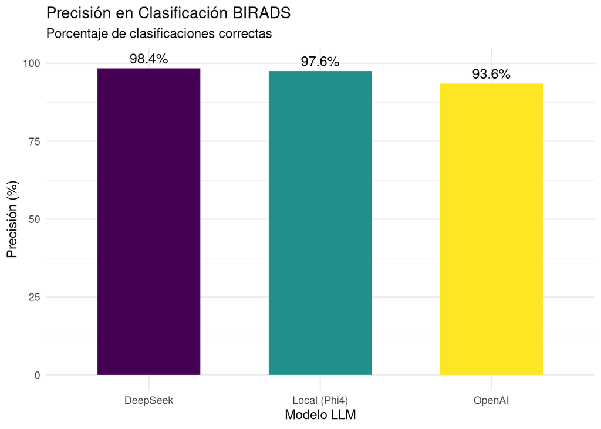

El modelo **DeepSeek** muestra la mayor precisión en la clasificación BIRADS (98.42%), seguido por **Local (Phi4)** (97.56%) y **OpenAI** (93.56%).

## Tasa de Alucinaciones (Menor es Mejor)

Las alucinaciones representan casos donde el modelo genera información incorrecta o no presente en la referencia.

[figure not shown]

**DeepSeek** muestra la menor tasa de alucinaciones, seguido por **OpenAI** y **Local (Phi4)**. Estos resultados indican que los modelos bajan la tasa de alucinaciones conforme aumenta su tamaño y complejidad.

## Precisión por Campo Específico

Analizamos la precisión de cada modelo en la identificación de hallazgos radiológicos específicos, comparando todos los campos disponibles en los informes.

Comparativa de precisión entre modelos LLM en transcripción de historias clínicas

| Campo clínico | Precisión (%) DeepSeek | Precisión (%) OpenAI | Precisión (%) Phi4 |
| --- | --- | --- | --- |
| Nódulos | 81.36% | 73.29% | 33.37% |
| Presencia Microcalcificaciones | 70.25% | 77.59% | 29.68% |
| Calcificaciones típicamente benignas | 89.18% | 74.91% | 20.14% |
| Calcificaciones morfología sospechosa | 58.57% | 52.58% | 16.27% |
| Distribución de las calcificaciones | 81.80% | 71.94% | 28.93% |
| Presencia de asimetrías | 75.50% | 79.25% | 43.80% |
| Tipo de asimetría | 70.25% | 22.03% | 3.04% |
| Hallazgos asociados | 74.34% | 67.19% | 40.41% |
| Lateralidad hallazgo | 72.13% | 63.55% | 26.48% |
| BIRADS | 94.65% | 92.56% | 90.65% |

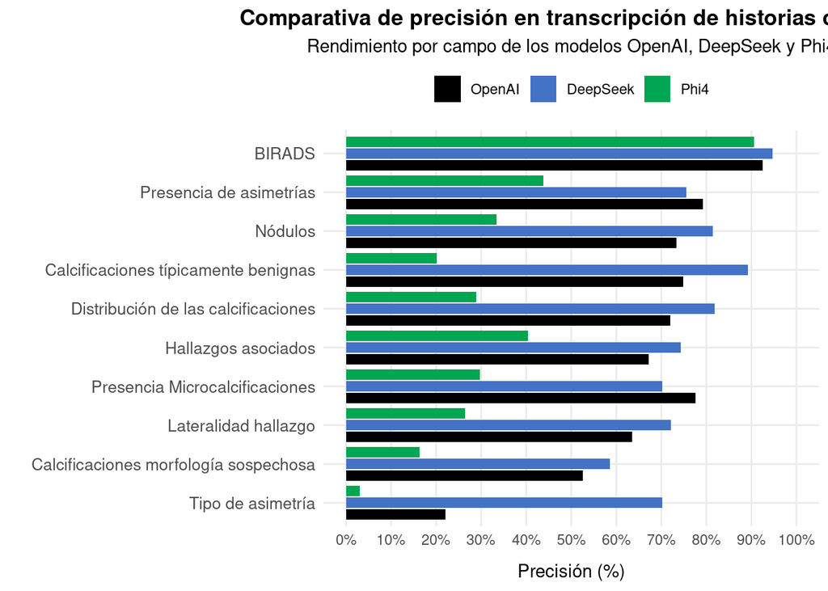

# Precios

Los precios de los modelos LLM varían según el proveedor y las características específicas de cada modelo. A continuación, se presentan los precios estimados para cada modelo:

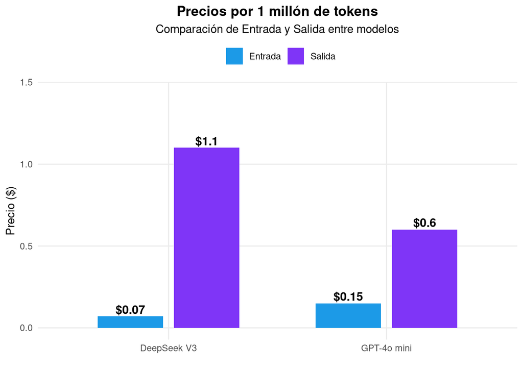

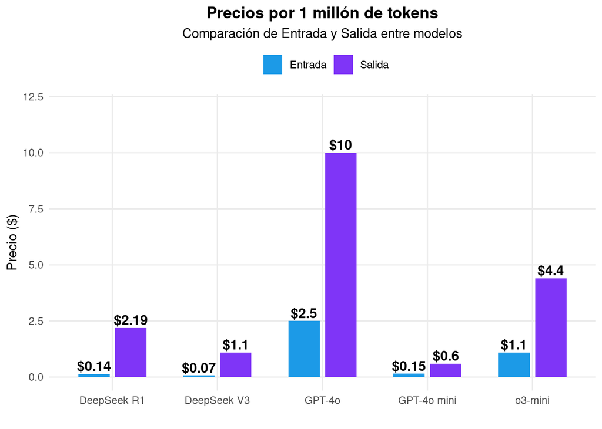